# MEGH: A parametric class of mixed-effects general hazard models

[F. Javier Rubio](https://sites.google.com/site/fjavierrubio67/) and Reza Drikvandi

13 March, 2022

# Leukemia data set and Survival Models

We analyse a data set (`LeukSurv`) on survival of acute myeloid leukemia available in the R package *spBayesSurv* (Zhou and Hanson 2018), which contains information about $n = 1043$ patients. We use information about survival time (years), vital status at the end of follow-up (0 - right-censored, 1 - dead), age (in years), sex (0 - female, 1 - male), white blood cell count at diagnosis (*wbc*, truncated at 500), the Townsend score (*tpi*, higher values indicates less affluent areas), and administrative district of residence (*district*, 24 districts). We fit models with hazard structures ME-I and ME-II (Rubio and Drikvandi 2022+);
$$h_1(t_{ij}\mid {\bf x}_{ij}, {\bf u}_i) = h_0\left(t_{ij} \exp\left\{\tilde{{\bf x}}_{ij}^{\top}\alpha\right\}\right)\exp\left\{{\bf x}_{ij}^{\top}\beta + {\bf z}_{ij}^{\top}{\bf u}_i \right\},$$

$$h_2(t_{ij}\mid {\bf x}_{ij}, {\bf u}_i) = h_0\left(t_{ij} \exp\left\{\tilde{{\bf x}}_{ij}^{\top}\alpha + {\bf z}_{ij}^{\top}{\bf u}_i \right\}\right)\exp\left\{{\bf x}_{ij}^{\top}\beta + {\bf z}_{ij}^{\top}{\bf u}_i \right\},$$

with PGW and log-logistic baseline hazards; and normal, Student-$t$ and two-piece normal random effects distributions. In all models, we consider the time dependent effect of age (normalised), and the hazard-level effects of age (normalised), sex, *wbc* and *tpi*. The variable *district* is used to define the random effects in the two mixed hazard structures considered. In addition, we fit the models without random effects in order to assess the need for including them.

# Data preparation

```r
rm(list = ls())
# install_github("FJRubio67/GHSurv")
library(GHSurv)
# install_github("FJRubio67/MEGH")
library(MEGH)
# install_github("FJRubio67/twopiece")
library(twopiece)
library(knitr)
library(survival)
library(matrixStats)
library(numDeriv)
library(spBayesSurv)
library(mvtnorm)
library(BayesX)
library(R2BayesX)
library(sp)
library(fields)
library(surveillance)
library(ggplot2)
library(latex2exp)
library(Rmisc)
library(matrixcalc)
library(survminer)
library(MASS)

#----------------------------------------------------------------------------------------------
# Example: Leukemia data
#---------------------------------------------------------------------------------------------

data(LeukSurv)
?LeukSurv
head(LeukSurv)
```

```
##   time cens    xcoord    ycoord age sex   wbc   tpi district
## 1    1    1 0.2050717 0.4972437  61   0  13.3 -1.96        9
## 2    1    1 0.2855568 0.8489526  76   0 450.0 -3.39        7
## 3    1    1 0.1764057 0.7364939  74   0 154.0 -4.95        7
## 4    1    1 0.2447630 0.2105843  79   1 500.0 -1.40       24
## 5    1    1 0.3274531 0.9073870  83   1 160.0 -2.59        7
## 6    1    1 0.6383682 0.3627343  81   1  30.4  0.03       11
```

```r
dim(LeukSurv)
```

```
## [1] 1043    9
```

```r
#******************
# Data preparation
#******************

n.ind <- dim(LeukSurv)[1]  # number of individuals
n.clust <- length(unique(LeukSurv$district)) # number of clusters
# Design matrices
X <- as.matrix(cbind(scale(LeukSurv$age), LeukSurv$sex, scale(LeukSurv$wbc), scale(LeukSurv$tpi) ))
colnames(X) <- cbind("std age", "sex", "wbc", "tpi")
Xt <- as.matrix(cbind(scale(LeukSurv$age)))
q <- dim(Xt)[2]
p <- dim(X)[2]
r <- n.clust

# Histogram of survival times
hist(LeukSurv$time/365.24, breaks = 50, probability = T,
     xlab = "Time (years)", ylab = "Density", main = "LeukSurv")
box()

# Required quantities
status <- as.vector(LeukSurv$cens)
times <- as.vector(LeukSurv$time)/365.24 # in years
ID <- as.vector(LeukSurv$district)
n.obs <- sum(status)

# Checking design matrices

# random-effects design matrix test
ZID <- matrix(0, ncol = r, nrow = n.ind)
for(i in 1:n.ind) ZID[i,ID[i]] <- 1

MZ <- as.matrix(t(ZID)%*%ZID)
MZ.obs <- as.matrix(t(ZID[as.logical(status),])%*%ZID[as.logical(status),])

is.singular.matrix(MZ)
```

```
## [1] FALSE
```

```r
is.singular.matrix(MZ.obs)
```

```
## [1] FALSE
```

```r
# Hazard scale design matrix test
MX <- as.matrix(t(X)%*%X)
MX.obs <- as.matrix(t(X[as.logical(status),])%*%X[as.logical(status),])

is.singular.matrix(MX)
```

```
## [1] FALSE
```

```r
is.singular.matrix(MX.obs)
```

```
## [1] FALSE
```

```r
# Time scale design matrix test
MXt <- as.matrix(t(Xt)%*%Xt)
MXt.obs <- as.matrix(t(Xt[as.logical(status),])%*%Xt[as.logical(status),])

is.singular.matrix(MXt)
```

```
## [1] FALSE
```

```r
is.singular.matrix(MXt.obs)
```

```
## [1] FALSE
```

[figure not shown]

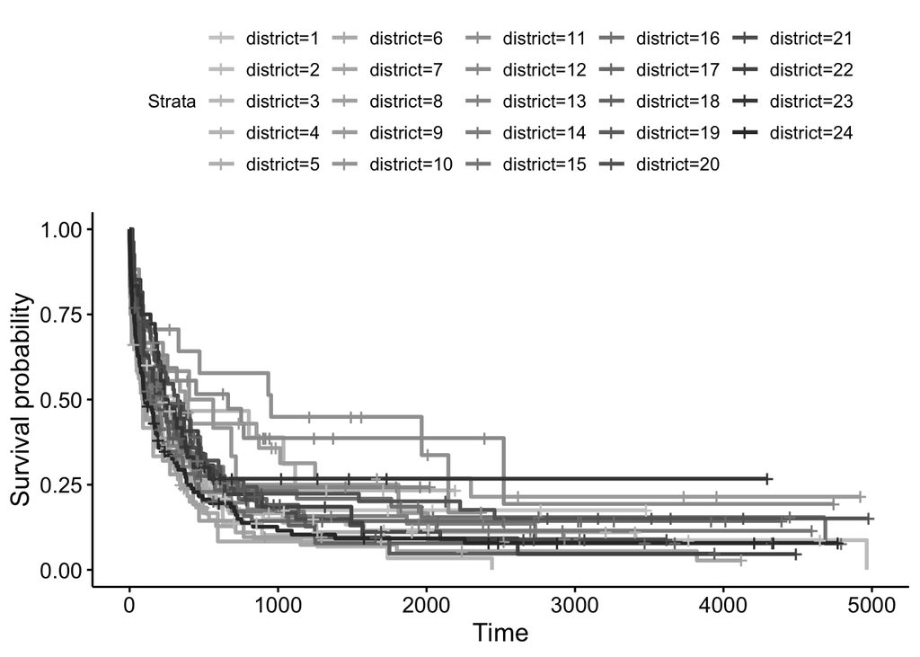

```r
################################################################################
# Comparison of Kaplan-Meier curves by district
################################################################################

fit <- survfit(Surv(time, cens) ~ district,
               data = LeukSurv)


ggsurvplot(fit, data = LeukSurv, risk.table = FALSE, linetype = 1, palette = "grey")
```

```r
################################################################################
# G-rho test to compare the survival curves by district
################################################################################

surv_diff <- survdiff(Surv(time, cens) ~ district, data = LeukSurv)
surv_diff
```

```
## Call:
## survdiff(formula = Surv(time, cens) ~ district, data = LeukSurv)
##
##               N Observed Expected (O-E)^2/E (O-E)^2/V
## district=1   35       28     30.1  1.47e-01  1.53e-01
## district=2   69       62     60.9  2.06e-02  2.23e-02
## district=3   44       42     32.7  2.64e+00  2.76e+00
## district=4   15       11     13.6  5.11e-01  5.23e-01
## district=5   46       40     37.9  1.14e-01  1.20e-01
## district=6   12       11      8.1  1.04e+00  1.06e+00
## district=7   71       64     44.3  8.71e+00  9.25e+00
## district=8   25       22     16.3  2.02e+00  2.07e+00
## district=9   34       24     34.4  3.13e+00  3.28e+00
## district=10  12       11     12.6  2.14e-01  2.18e-01
## district=11  17       11     21.3  4.99e+00  5.16e+00
## district=12  27       17     30.2  5.75e+00  5.99e+00
## district=13  18       13     15.9  5.35e-01  5.48e-01
## district=14  58       50     50.2  7.54e-04  8.04e-04
## district=15  37       32     32.0  3.96e-05  4.13e-05
## district=16  52       43     47.7  4.65e-01  4.95e-01
## district=17  84       69     62.8  6.08e-01  6.60e-01
## district=18  45       39     40.6  6.00e-02  6.32e-02
## district=19  61       51     49.1  7.74e-02  8.25e-02
## district=20  53       44     48.4  3.92e-01  4.20e-01
## district=21  63       54     59.5  5.09e-01  5.49e-01
## district=22  27       25     26.3  6.11e-02  6.33e-02
## district=23  36       26     32.1  1.15e+00  1.20e+00
## district=24 102       90     72.0  4.48e+00  4.91e+00
##
##  Chisq= 38.3  on 23 degrees of freedom, p= 0.02
```

# Models without random effects

```r
############################################################
# Ignoring random effects
############################################################

# Optimisation step

# LN baseline
OPT0 <- GHMLE(init = rep(0,2+p+q), times = times, status = status, hstr = "LNGH",
              des = X, des_t = Xt, method = "nlminb", maxit = 10000)
# PGW baseline
OPT1 <- GHMLE(init = rep(0,3+p+q), times = times, status = status, hstr = "PGWGH",
              des = X, des_t = Xt, method = "nlminb", maxit = 10000)
# GG baseline
OPT2 <- GHMLE(init = rep(0,2+p+q), times = times, status = status, hstr = "GGH",
              des = X, des_t = Xt, method = "nlminb", maxit = 10000)
# LL baseline
OPT3 <- GHMLE(init = rep(0,2+p+q), times = times, status = status, hstr = "LLGH",
              des = X, des_t = Xt, method = "nlminb", maxit = 10000)

# Comparing models without random effects
AIC00 <- 2*OPT0$OPT$objective + 2*length(OPT0$OPT$par)
AIC01 <- 2*OPT1$OPT$objective + 2*length(OPT1$OPT$par)
AIC02 <- 2*OPT2$OPT$objective + 2*length(OPT2$OPT$par)
AIC03 <- 2*OPT3$OPT$objective + 2*length(OPT3$OPT$par)

AIC0s <- c(AIC00,AIC01,AIC02,AIC03)
which.min(AIC0s)
```

```
## [1] 4
```

```r
# Best model is the one with log-logistic baseline hazard
MLE <- c(OPT3$OPT$par[1],exp(OPT3$OPT$par[2]),OPT3$OPT$par[-c(1:2)])
AIC0 <- 2*OPT3$OPT$objective + 2*length(OPT3$OPT$par)
```

# Models with random effects

```r
############################################################
# Models with random effects
############################################################

#--------------------------------
# Required quantities
#--------------------------------

#------------------------------------------------
# Marginal likelihoods
#------------------------------------------------

# Normal random effects (PGW baseline)
ml1 <- function(par) -ml1_PGW_rep(par = par, times, status, des = X, des_t = Xt, n.clust = n.clust)
ml2 <- function(par) -ml2_PGW_rep(par = par, times, status, des = X, des_t = Xt, n.clust = n.clust)

# Student-t random effects (PGW baseline)
tml1 <- function(par) -tml1_PGW_rep(par = par, times, status, des = X, des_t = Xt, n.clust = n.clust)
tml2 <- function(par) -tml2_PGW_rep(par = par, times, status, des = X, des_t = Xt, n.clust = n.clust)

# Student-t random effects (PGW baseline)
tpnml1 <- function(par) -tpnml1_PGW_rep(par = par, times, status, des = X, des_t = Xt, n.clust = n.clust)
tpnml2 <- function(par) -tpnml2_PGW_rep(par = par, times, status, des = X, des_t = Xt, n.clust = n.clust)

# Normal random effects (log-logistic baseline)
ml11 <- function(par) -ml1_LL_rep(par = par, times, status, des = X, des_t = Xt, n.clust = n.clust)
ml21 <- function(par) -ml2_LL_rep(par = par, times, status, des = X, des_t = Xt, n.clust = n.clust)

# Student-t random effects (log-logistic baseline)
tml11 <- function(par) -tml1_LL_rep(par = par, times, status, des = X, des_t = Xt, n.clust = n.clust)
tml21 <- function(par) -tml2_LL_rep(par = par, times, status, des = X, des_t = Xt, n.clust = n.clust)

# Student-t random effects (log-logistic baseline)
tpnml11 <- function(par) -tpnml1_LL_rep(par = par, times, status, des = X, des_t = Xt, n.clust = n.clust)
tpnml21 <- function(par) -tpnml2_LL_rep(par = par, times, status, des = X, des_t = Xt, n.clust = n.clust)

#------------------------------------------------
# Optimisation
#------------------------------------------------

# Normal random effects (PGW baseline)
OPTMEN1 <- nlminb(c(0,OPT1$OPT$par), ml1, control = list(iter.max = 10000))
OPTMEN2 <- nlminb(c(0,OPT1$OPT$par), ml2, control = list(iter.max = 10000))

# Student-t random effects (PGW baseline)
OPTMET1 <- nlminb(c(0,1,OPT1$OPT$par), tml1, control = list(iter.max = 10000))
OPTMET2 <- nlminb(c(0,1,OPT1$OPT$par), tml2, control = list(iter.max = 10000))

# TPN random effects (PGW baseline)
OPTMETPN1 <- nlminb(c(0,0,OPT1$OPT$par), tpnml1, control = list(iter.max = 10000))
OPTMETPN2 <- nlminb(c(0,0,OPT1$OPT$par), tpnml2, control = list(iter.max = 10000))

# Normal random effects (log-logistic baseline)
OPTMEN11 <- nlminb(c(0,OPT3$OPT$par), ml11, control = list(iter.max = 10000))
OPTMEN21 <- nlminb(c(0,OPT3$OPT$par), ml21, control = list(iter.max = 10000))

# Student-t random effects (log-logistic baseline)
OPTMET11 <- nlminb(c(0,1,OPT3$OPT$par), tml11, control = list(iter.max = 10000))
OPTMET21 <- nlminb(c(0,1,OPT3$OPT$par), tml21, control = list(iter.max = 10000))

# TPN random effects (log-logistic baseline)
OPTMETPN11 <- nlminb(c(0,0,OPT3$OPT$par), tpnml11, control = list(iter.max = 10000))
OPTMETPN21 <- nlminb(c(0,0,OPT3$OPT$par), tpnml21, control = list(iter.max = 10000))


#------------------------------------------------
# Marginal Maximum Likelihood Estimators
#------------------------------------------------

# PGW
MMLEN1 <- c(exp(OPTMEN1$par[1:4]),OPTMEN1$par[-c(1:4)])
MMLEN2 <- c(exp(OPTMEN2$par[1:4]),OPTMEN2$par[-c(1:4)])

MMLET1 <- c(exp(OPTMEN1$par[1:5]),OPTMET1$par[-c(1:5)])
MMLET2 <- c(exp(OPTMEN2$par[1:5]),OPTMET2$par[-c(1:5)])

MMLETPN1 <- c(exp(OPTMETPN1$par[1]),tanh(OPTMETPN1$par[2]),exp(OPTMETPN1$par[3:5]),OPTMETPN1$par[-c(1:5)])
MMLETPN2 <- c(exp(OPTMETPN2$par[1]),tanh(OPTMETPN2$par[2]),exp(OPTMETPN2$par[3:5]),OPTMETPN2$par[-c(1:5)])

# Log logistic
MMLEN11 <- c(exp(OPTMEN11$par[1]),OPTMEN11$par[2],exp(OPTMEN11$par[3]),OPTMEN11$par[-c(1:3)])
MMLEN21 <- c(exp(OPTMEN21$par[1]),OPTMEN21$par[2],exp(OPTMEN21$par[3]),OPTMEN21$par[-c(1:3)])

MMLET11 <- c(exp(OPTMET11$par[1:2]),OPTMET11$par[3],exp(OPTMET11$par[4]),OPTMET11$par[-c(1:4)])
MMLET21 <- c(exp(OPTMET21$par[1:2]),OPTMET21$par[3],exp(OPTMET21$par[4]),OPTMET21$par[-c(1:4)])

MMLETPN11 <- c(exp(OPTMETPN11$par[1]),tanh(OPTMETPN11$par[2]),OPTMETPN11$par[3],exp(OPTMETPN11$par[4]),OPTMETPN11$par[-c(1:4)])
MMLETPN21 <- c(exp(OPTMETPN21$par[1]),tanh(OPTMETPN21$par[2]),OPTMETPN21$par[3],exp(OPTMETPN21$par[4]),OPTMETPN21$par[-c(1:4)])
```

# Model Comparison

```r
#------------------------------------------------
# AIC for mixed models
#------------------------------------------------
AIC1 <- 2*OPTMEN1$objective + 2*length(OPTMEN1$par)
AIC2 <- 2*OPTMEN2$objective + 2*length(OPTMEN2$par)

AICT1 <- 2*OPTMET1$objective + 2*length(OPTMET1$par)
AICT2 <- 2*OPTMET2$objective + 2*length(OPTMET2$par)

AICTPN1 <- 2*OPTMETPN1$objective + 2*length(OPTMETPN1$par)
AICTPN2 <- 2*OPTMETPN2$objective + 2*length(OPTMETPN2$par)

AIC11 <- 2*OPTMEN11$objective + 2*length(OPTMEN11$par)
AIC21 <- 2*OPTMEN21$objective + 2*length(OPTMEN21$par)

AICT11 <- 2*OPTMET11$objective + 2*length(OPTMET11$par)
AICT21 <- 2*OPTMET21$objective + 2*length(OPTMET21$par)

AICTPN11 <- 2*OPTMETPN11$objective + 2*length(OPTMETPN11$par)
AICTPN21 <- 2*OPTMETPN21$objective + 2*length(OPTMETPN21$par)

#-----------------------------------------------------------------
# Model comparison: no RE, MEGH-I, MEGH-II
#-----------------------------------------------------------------

AICs <- c(AIC0,AIC1,AIC2,AICT1,AICT2,AICTPN1,AICTPN2,
          AIC11,AIC21,AICT11,AICT21,AICTPN11,AICTPN21)

min(AICs)
```

```
## [1] 1553.725
```

```r
ind.min <- which.min(AICs)
ind.min
```

```
## [1] 8
```

```r
# Best model
mod.names <- c("LL", "PGW-N1", "PGW-N2", "PGW-T1", "PGW-T2", "PGW-TPN1", "PGW-TPN2",
               "LL-N1", "LL-N2", "LL-T1", "LL-T2", "LL-TPN1", "LL-TPN2")

mod.names[ind.min]
```

```
## [1] "LL-N1"
```

```r
OPTME <- OPTMEN11

#-----------------------------------------------------------------
# MLE vs. MMLE comparison
#-----------------------------------------------------------------

EST <- as.matrix(cbind(c(NA,MLE), MMLEN11))
colnames(EST) <- c("MLE", "MMLE")

kable(EST, digits = 3)
```

| MLE | MMLE |
| --- | --- |
| NA | 0.144 |
| -0.681 | -0.650 |
| 1.167 | 1.163 |
| 0.800 | 0.762 |
| 0.940 | 0.932 |
| 0.084 | 0.092 |
| 0.220 | 0.224 |
| 0.102 | 0.104 |

# Likelihood Ratio Test

```r
#############################################################
#Likelihood ratio test (LRT) for testing the random effect u
# log-logistic baseline
#############################################################
LRT_statistic <- -2*(OPTMEN11$objective-OPT3$OPT$objective)
#test for random effects based on the mixture of chi-squared distributions
p_value=.5*(1-pchisq(LRT_statistic,0))+.5*(1-pchisq(LRT_statistic,1))
print(paste("p_value=",p_value))
```

```
## [1] "p_value= 0.0156104393238179"
```

```r
if(p_value<0.05){print("Here we can reject H0:sigma=0, so the random effect is significant and must be present in the model")}else{print("Here we cannot reject H0:sigma=0, so the random effect is not significant and must be removed from the model")}
```

```
## [1] "Here we can reject H0:sigma=0, so the random effect is significant and must be present in the model"
```

# Gradient Function

## Normal random effects

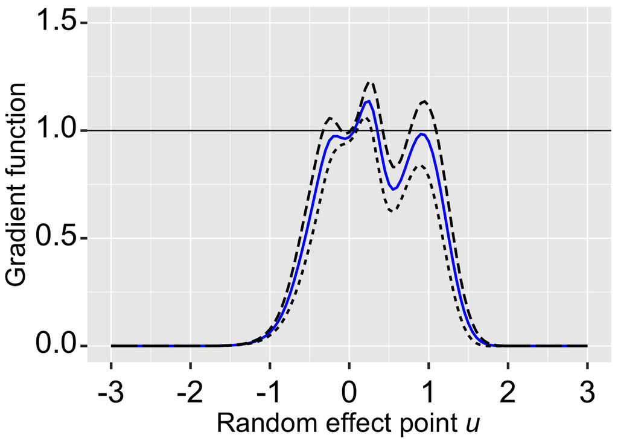

```r
############################################################
#Gradient function with new confidence bounds for log-logistic baseline
############################################################

# MMLES of the best model in the original scale
 MMLE <- c(exp(OPTMEN11$par[1]),OPTMEN11$par[2],exp(OPTMEN11$par[3]),OPTMEN11$par[-c(1:3)])

#for normal random effects
new_ml1 <- function(par) -ml1_LL(par = par, times, status, des = X, des_t = Xt, n.clust = n.clust)
def_ml1 <- function(pars){
  return(new_ml1(pars))
}
hess <- hessian(def_ml1,x=MMLE)
FisherS <- solve(hess)
M=n.clust
set.seed(1)
MMLEsim <- mvrnorm(n=M,mu=MMLE, Sigma=FisherS)

#calculate the actual gradient values
ind.min <- 8
uu <- seq(-3,3,by=0.05) #uu is a grid of random effect points
ratio <- numeric(r)
gradient <- numeric(length(uu))
for(k in 1:length(uu))
{
  for(i in 1:r)
  {
    if(ind.min==8)
    {
      MMLE <- c(exp(OPTMEN11$par[1]),OPTMEN11$par[2],exp(OPTMEN11$par[3]),OPTMEN11$par[-c(1:3)])
      num <- exp(log_likCInd1_LL(MMLE[-1],uu[k],times, status, des = X, des_t = Xt, index = i))
      den <- exp(ml1Ind_LL(MMLE,times, status, des = X, des_t = Xt, index = i))
    } else if(ind.min==9)
    {
      MMLE <- c(exp(OPTMEN21$par[1]),OPTMEN21$par[2],exp(OPTMEN21$par[3]),OPTMEN21$par[-c(1:3)])
      num <- exp(log_likCInd2_LL(MMLE[-1],uu[k],times, status, des = X, des_t = Xt, index = i))
      den <- exp(ml2Ind_LL(MMLE,times, status, des = X, des_t = Xt, index = i))
    }
    ratio[i] <- num/den
  }
  gradient[k] <- mean(ratio)
}

  #calculate the new confidence bands for gradient
  ind.min=8
  gradient_sim <- matrix(0,length(uu),M)
  ratio <- numeric(r)
  gradient_lower <- numeric(length(uu))
  gradient_upper <- numeric(length(uu))
  for(k in 1:length(uu))
  {
   for(m in 1:M)
    {
     for(i in 1:r)
     {
        #for ind.min==8
        MMLEs <- MMLEsim[m,]
        num <- exp(log_likCInd1_LL(MMLEs[-1],uu[k],times, status, des = X, des_t = Xt, index = i))
        den <- exp(ml1Ind_LL(MMLEs,times, status, des = X, des_t = Xt, index = i))
        ratio[i] <- num/den
     }
     gradient_sim[k,m] <- mean(ratio)
   }
    gradient_upper[k] <- gradient[k]+qt(df=M-1,0.975)*sd(gradient_sim[k,])/sqrt(M)
    gradient_lower[k] <- gradient[k]-qt(df=M-1,0.975)*sd(gradient_sim[k,])/sqrt(M)
    #gradient_upper[k] <- quantile(gradient_sim[k,],0.975)
    #gradient_lower[k] <- quantile(gradient_sim[k,],0.025)
    #gradient_CI <- CI(gradient_sim[k,], ci=0.95)
    #gradient_upper[k] <- gradient_CI[1]
    #gradient_lower[k] <- gradient_CI[3]
 }

#use ggplot to plot the gradient function with the pointwise confidence bands
gradient_curve <- rep(1,length(gradient))
lower <- rep(2,length(gradient_lower))
upper <- rep(3,length(gradient_upper))
gradient_data <- cbind(c(uu,uu,uu),c(gradient,gradient_lower,gradient_upper),c(gradient_curve,lower,upper))
gradient_data <- as.data.frame(gradient_data)
colnames(gradient_data) <- c("RE_point","Gradient","bounds")
gradient_data$`bounds` <- factor(gradient_data$`bounds`,levels=c("1","2","3"))
gradient_data$`bounds` <- factor(gradient_data$`bounds`,levels=c("1","2","3"))
levels(gradient_data$`bounds`) <- c("Gradient_curve", "Lower","Upper")
ggplot(data=gradient_data, aes(x=RE_point, y=Gradient, group=bounds)) +
  geom_line(aes(colour=bounds, linetype=bounds), size=1) +
  scale_colour_manual(values = c("Gradient_curve"="blue", "Lower"="black", "Upper"="black")) +
  xlab(TeX("Random effect point \\textit{$u$}")) + ylab("Gradient function") +
  theme(axis.text.x = element_text(color="black", size = 25,vjust = -0.3), axis.text.y = element_text(color="black", size = 25,vjust = 0.3)) +
  theme(axis.ticks.x = element_line(size = 1), axis.ticks.y = element_line(size = 1), axis.ticks.length=unit(0.2,"cm")) +
  theme(axis.title.x=element_text(vjust=-0.5),axis.title.y=element_text(vjust=1.2)) +
  scale_x_continuous(breaks = c(-3,-2,-1,0,1,2,3)) +
  scale_y_continuous(breaks = c(0,0.5,1,1.5)) +
  theme(axis.title.y = element_text(size = rel(2), angle=90)) +
  theme(axis.title.x = element_text(size = rel(2), angle=0,face="italic")) +
  theme(legend.position="none",legend.background = element_rect(color = "grey", fill = "white", size = 1),
        legend.text=element_text(size=25)) + geom_hline(yintercept=1)+
  expand_limits(y=c(0,1.5))
```

## two-piece normal random effects

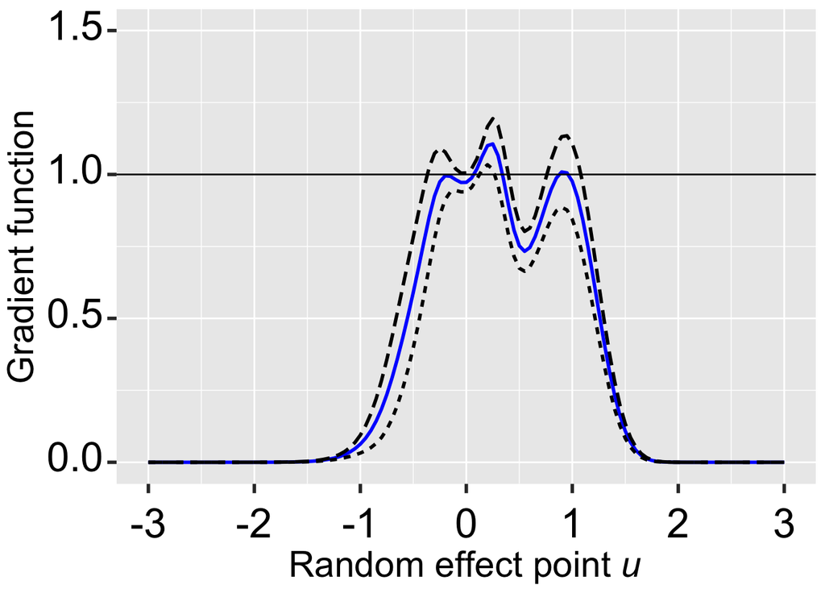

```r
#for two-piece normal random effects with new gradient bands
new_tpnml1 <- function(par) -tpnml1_LL(par = par, times, status, des = X, des_t = Xt, n.clust = n.clust)
def_tpnml1 <- function(pars){
  return(new_tpnml1(pars))
}
MMLETPN <- c(exp(OPTMETPN11$par[1]),tanh(OPTMETPN11$par[2]),OPTMETPN11$par[3],exp(OPTMETPN11$par[4]),OPTMETPN11$par[-c(1:4)])
hess_tpm <- hessian(def_tpnml1,x=MMLETPN)
FisherS_tpm <- solve(hess_tpm)
M=n.clust
set.seed(1)
MMLETPNsim <- mvrnorm(n=M,mu=MMLETPN, Sigma=FisherS_tpm)

#calculate the actual gradient values
ind.min=12
uu <- seq(-3,3,by=0.05) #uu is a grid of random effect points
ratio <- numeric(r)
gradient <- numeric(length(uu))
for(k in 1:length(uu))
{
  for(i in 1:r)
  {
    if(ind.min==12)
    {
      MMLETPN <- c(exp(OPTMETPN11$par[1]),tanh(OPTMETPN11$par[2]),OPTMETPN11$par[3],exp(OPTMETPN11$par[4]),OPTMETPN11$par[-c(1:4)])
      num <- exp(log_likCInd1_LL(MMLETPN[-c(1,2)],uu[k],times, status, des = X, des_t = Xt, index = i))
      den <- exp(tpnml1Ind_LL(MMLETPN,times, status, des = X, des_t = Xt, index = i))
    } else if(ind.min==13)
    {
      MMLETPN <- c(exp(OPTMETPN21$par[1]),tanh(OPTMETPN21$par[2]),OPTMETPN21$par[3],exp(OPTMETPN21$par[4]),OPTMETPN21$par[-c(1:4)])
      num <- exp(log_likCInd2_LL(MMLETPN[-c(1,2)],uu[k],times, status, des = X, des_t = Xt, index = i))
      den <- exp(tpnml2Ind_LL(MMLETPN,times, status, des = X, des_t = Xt, index = i))
    }
    ratio[i] <- num/den
  }
  gradient[k] <- mean(ratio)
}

#calculate the new confidence bands for gradient
ind.min=12
gradient_sim <- matrix(0,length(uu),M)
ratio <- numeric(r)
gradient_lower <- numeric(length(uu))
gradient_upper <- numeric(length(uu))
for(k in 1:length(uu))
{
  for(m in 1:M)
  {
    for(i in 1:r)
    {
      #for ind.min==12
      MMLETPNs <- MMLETPNsim[m,]
      num <- exp(log_likCInd1_LL(MMLETPNs[-c(1,2)],uu[k],times, status, des = X, des_t = Xt, index = i))
      den <- exp(tpnml1Ind_LL(MMLETPNs,times, status, des = X, des_t = Xt, index = i))
      ratio[i] <- num/den
    }
    gradient_sim[k,m] <- mean(ratio)
  }
  gradient_upper[k] <- gradient[k]+qt(df=M-1,0.975)*sd(gradient_sim[k,])/sqrt(M)
  gradient_lower[k] <- gradient[k]-qt(df=M-1,0.975)*sd(gradient_sim[k,])/sqrt(M)
  #gradient_upper[k] <- quantile(gradient_sim[k,],0.975)
  #gradient_lower[k] <- quantile(gradient_sim[k,],0.025)
  #gradient_CI <- CI(gradient_sim[k,], ci=0.95)
  #gradient_upper[k] <- gradient_CI[1]
  #gradient_lower[k] <- gradient_CI[3]
}

#use ggplot to plot the gradient function with the pointwise confidence bands
gradient_curve <- rep(1,length(gradient))
lower <- rep(2,length(gradient_lower))
upper <- rep(3,length(gradient_upper))
gradient_data <- cbind(c(uu,uu,uu),c(gradient,gradient_lower,gradient_upper),c(gradient_curve,lower,upper))
gradient_data <- as.data.frame(gradient_data)
colnames(gradient_data) <- c("RE_point","Gradient","bounds")
gradient_data$`bounds` <- factor(gradient_data$`bounds`,levels=c("1","2","3"))
gradient_data$`bounds` <- factor(gradient_data$`bounds`,levels=c("1","2","3"))
levels(gradient_data$`bounds`) <- c("Gradient_curve", "Lower","Upper")
ggplot(data=gradient_data, aes(x=RE_point, y=Gradient, group=bounds)) +
  geom_line(aes(colour=bounds, linetype=bounds), size=1) +
  scale_colour_manual(values = c("Gradient_curve"="blue", "Lower"="black", "Upper"="black")) +
  xlab(TeX("Random effect point \\textit{$u$}")) + ylab("Gradient function") +
  theme(axis.text.x = element_text(color="black", size = 25,vjust = -0.3), axis.text.y = element_text(color="black", size = 25,vjust = 0.3)) +
  theme(axis.ticks.x = element_line(size = 1), axis.ticks.y = element_line(size = 1), axis.ticks.length=unit(0.2,"cm")) +
  theme(axis.title.x=element_text(vjust=-0.5),axis.title.y=element_text(vjust=1.2)) +
  scale_x_continuous(breaks = c(-3,-2,-1,0,1,2,3)) +
  scale_y_continuous(breaks = c(0,0.5,1,1.5)) +
  theme(axis.title.y = element_text(size = rel(2), angle=90)) +
  theme(axis.title.x = element_text(size = rel(2), angle=0,face="italic")) +
  theme(legend.position="none",legend.background = element_rect(color = "grey", fill = "white", size = 1),
        legend.text=element_text(size=25)) + geom_hline(yintercept=1)+
  expand_limits(y=c(0,1.5))
```

# Estimates comparison

```r
# Confidence interval (positive parameters are in the log-scale and the skewness parameter in tanh scale)
CIm1 <- Conf.Int(ml11,OPTMEN11$par,level=0.95)
CIm2 <- Conf.Int(ml21,OPTMEN21$par,level=0.95)
CIm0 <- Conf.Int(FUN=OPT3$loglik,MLE = OPT3$OPT$par,level=0.95)

# Transforming the CIs to the original scale
CIm1[c(1,3),] <- exp(CIm1[c(1,3),] )
CIm2[c(1,3),] <- exp(CIm2[c(1,3),] )
CIm0[c(1),] <- exp(CIm0[c(1),] )

kable(CIm0[,-4], digits = 3)
```

|  | Lower | Upper | Transf MLE |
| --- | --- | --- | --- |
| par1 | 0.427 | 0.600 | 0.506 |
| par2 | 0.096 | 0.212 | 0.154 |
| par3 | 0.489 | 1.112 | 0.800 |
| par4 | 0.773 | 1.106 | 0.940 |
| par5 | -0.045 | 0.214 | 0.084 |
| par6 | 0.157 | 0.283 | 0.220 |
| par7 | 0.037 | 0.166 | 0.102 |

```r
kable(CIm1[,-4], digits = 3)
```

|  | Lower | Upper | Transf MLE |
| --- | --- | --- | --- |
| par1 | 0.070 | 0.296 | 0.144 |
| par2 | -0.848 | -0.451 | -0.650 |
| par3 | 1.096 | 1.235 | 1.163 |
| par4 | 0.447 | 1.076 | 0.762 |
| par5 | 0.765 | 1.098 | 0.932 |
| par6 | -0.039 | 0.223 | 0.092 |
| par7 | 0.159 | 0.288 | 0.224 |
| par8 | 0.035 | 0.173 | 0.104 |

```r
kable(CIm2[,-4], digits = 3)
```

|  | Lower | Upper | Transf MLE |
| --- | --- | --- | --- |
| par1 | 0.144 | 0.295 | 0.206 |
| par2 | -0.776 | -0.563 | -0.670 |
| par3 | 1.125 | 1.197 | 1.160 |
| par4 | 0.657 | 0.933 | 0.795 |
| par5 | 0.860 | 1.025 | 0.943 |
| par6 | 0.071 | 0.109 | 0.090 |
| par7 | 0.179 | 0.263 | 0.221 |
| par8 | 0.076 | 0.121 | 0.098 |

```r
# MMLES of the best model in the original scale
MMLE <- c(exp(OPTME$par[1]),OPTME$par[2],exp(OPTME$par[3]),OPTME$par[-c(1:3)])

# Comparing MLE and MMLE
round(MLE, digits = 3)
```

```
## [1] -0.681  1.167  0.800  0.940  0.084  0.220  0.102
```

```r
round(MMLE, digits = 3)
```

```
## [1]  0.144 -0.650  1.163  0.762  0.932  0.092  0.224  0.104
```

# Marginal Survival Maps

```r
########################################################################################################
# Maps of marginal survival functions at times t = 1, 5 years
########################################################################################################

# Map object
nwengland <- read.bnd(system.file("otherdata/nwengland.bnd",
                                  package = "spBayesSurv"))
```

```
## Note: map consists of 29 polygons
## Note: map consists of 24 regions
## Reading map ... finished
```

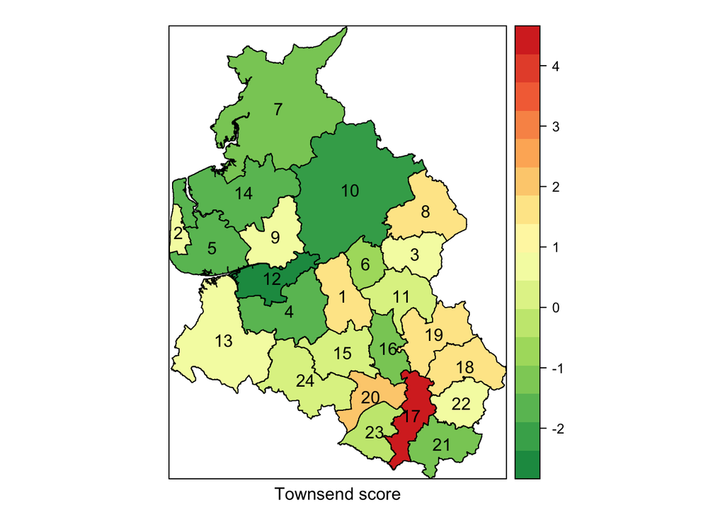

```r
nwsp = bnd2sp(nwengland)

# Aggregated data
surv1 <- surv5 <- vector()

for(i in 1:r) surv1[i] <- MSurvLL1(1, par= MMLE, des = X, des_t = Xt, index = i, NMC = 10000)
for(i in 1:r) surv5[i] <- MSurvLL1(5, par= MMLE, des = X, des_t = Xt, index = i, NMC = 10000)


psurvs1 = SpatialPolygonsDataFrame(nwsp, aggregate(surv1[LeukSurv$district],
                                                   list(d=LeukSurv$district),
                                                   function(v){mean(v)}))

psurvs5 = SpatialPolygonsDataFrame(nwsp, aggregate(surv5[LeukSurv$district],
                                                   list(d=LeukSurv$district),
                                                   function(v){mean(v)}))

map.tpi = SpatialPolygonsDataFrame(nwsp, aggregate(LeukSurv$tpi,
                                                   list(d=LeukSurv$district),
                                                   function(v){mean(v)}))


map.age = SpatialPolygonsDataFrame(nwsp, aggregate(LeukSurv$age,
                                                   list(d=LeukSurv$district),
                                                   function(v){mean(v)}))

library(RColorBrewer)

#colorscheme <- gray.colors(256)

colorscheme <- adjustcolor(colorRampPalette(brewer.pal(n=9, 'RdYlGn'))(100), 1)

# Map plots of survival and Townsend score
li1 <- layout.labels(map.tpi, labels = list(font=1, labels="district"))
li2 <- layout.scalebar(map.tpi, scale = 5, corner = c(-1, -1))

spplot(map.tpi,"x", sp.layout = c(list(li1), li2), col = "black", col.regions = rev(colorscheme), xlab = "Townsend score")
```

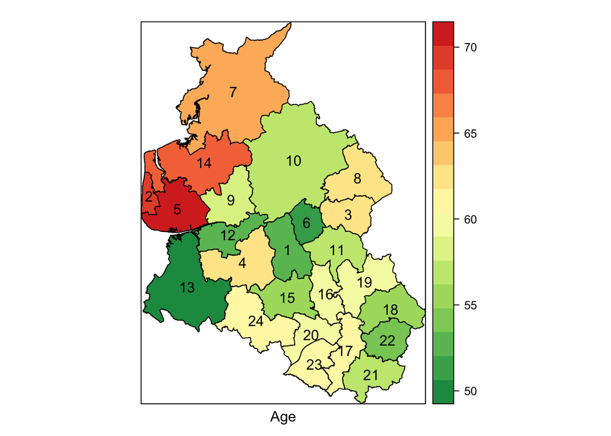

```r
spplot(map.age,"x", sp.layout = c(list(li1), li2), col = "black", col.regions = rev(colorscheme), xlab = "Age")
```

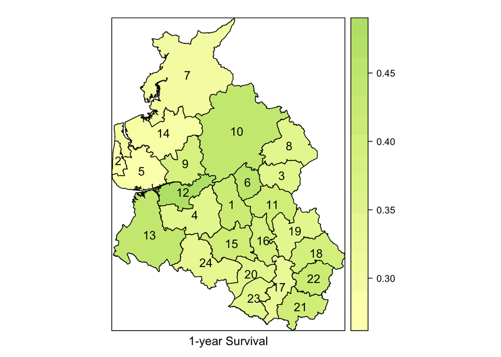

```r
spplot(psurvs1,"x", sp.layout = c(list(li1), li2), col = "black", col.regions = colorscheme[51:70], xlab = "1-year Survival")
```

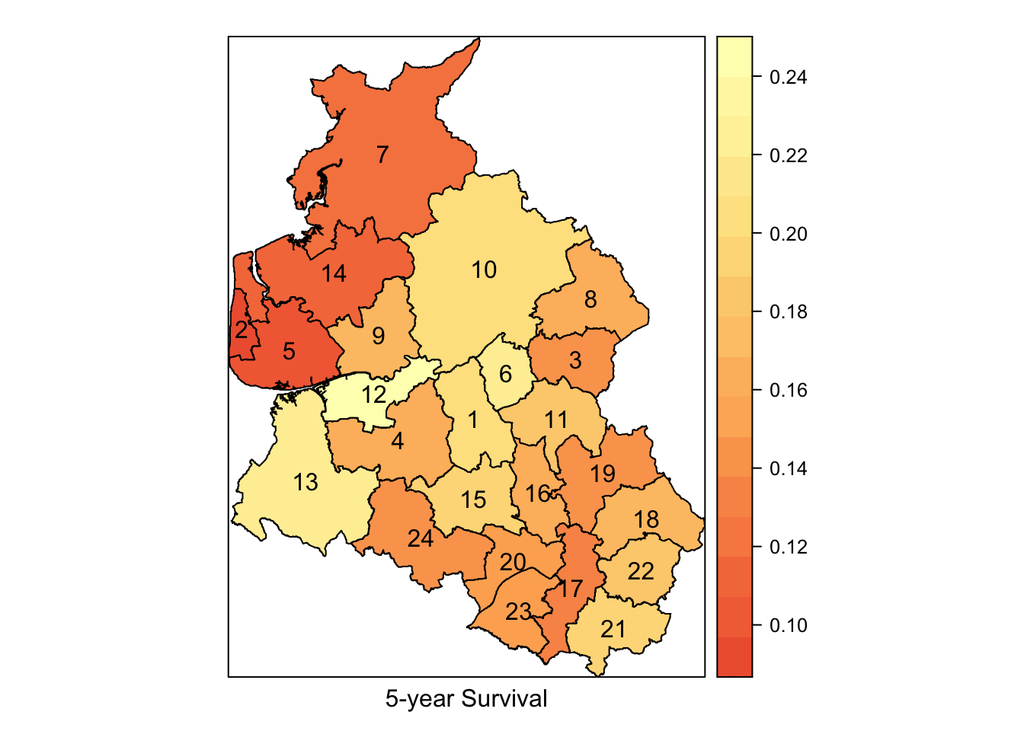

```r
spplot(psurvs5,"x", sp.layout = c(list(li1), li2), col = "black", col.regions = colorscheme[11:50], xlab = "5-year Survival")
```

# References

Rubio, F. J., and R. Drikvandi. 2022+. “MEGH: A Parametric Class of Mixed-Effects General Hazard Models.” *Preprint* na (2022+): na–.

Zhou, H., and T. Hanson. 2018. “A Unified Framework for Fitting Bayesian Semiparametric Models to Arbitrarily Censored Survival Data, Including Spatially Referenced Data.” *Journal of the American Statistical Association* 113 (522): 571–81.